# Data Mining - Handin 1 - Clustering

### Task 4.1.2 (2 points)

A) **[Implement]** DBOutliers requires tuning the parameters eps, pi. Run the code from Task 4.1.1 with different choices of eps, pi

**Note** that the data is normalized. Choose two ranges with **at least** 4 values each.

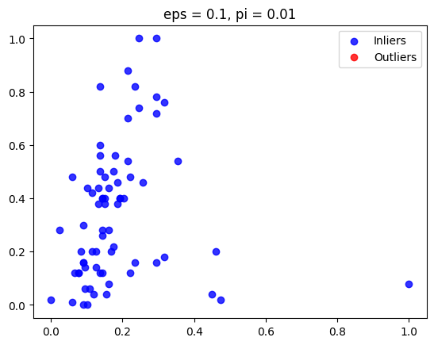

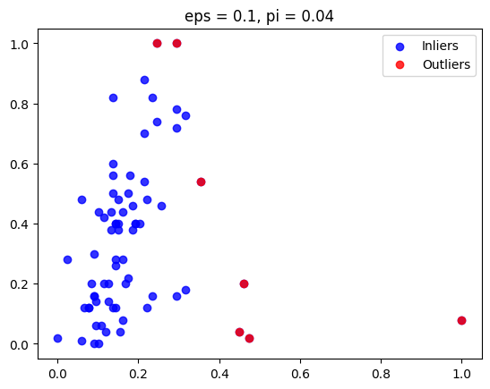

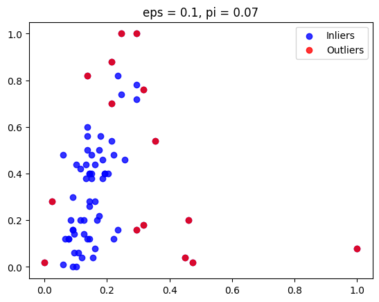

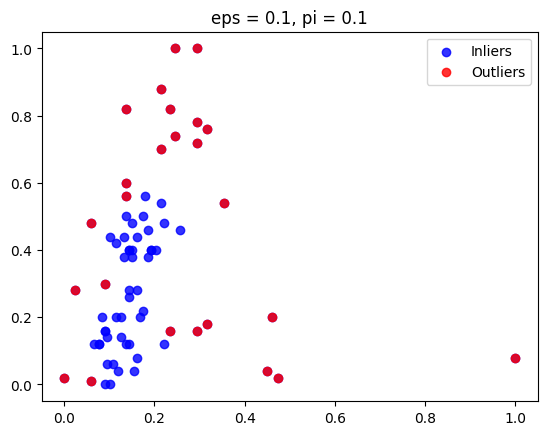

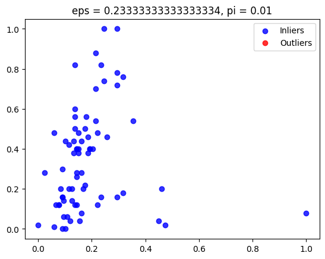

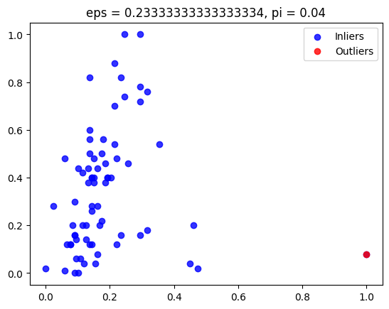

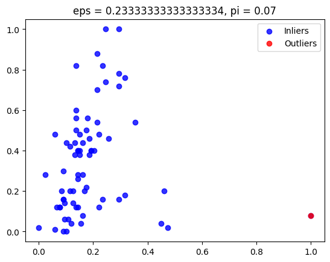

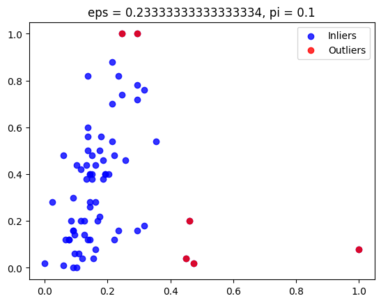

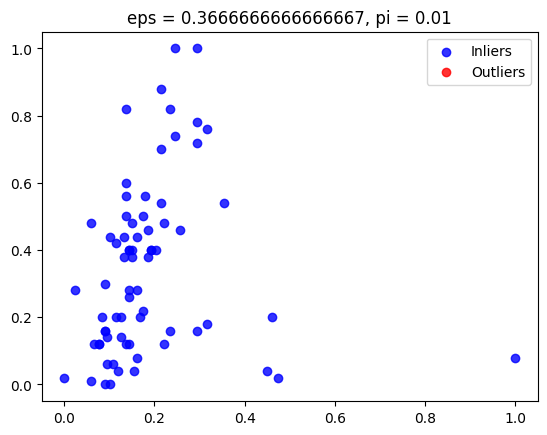

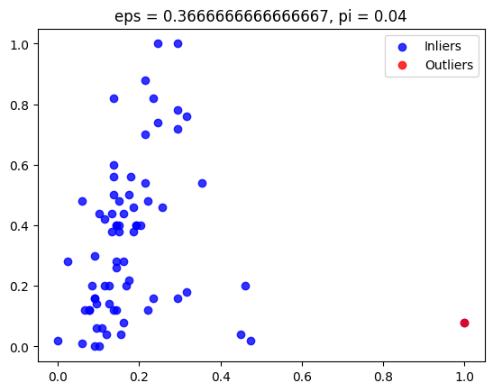

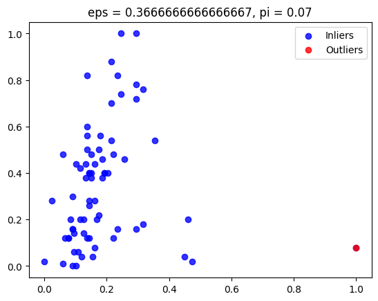

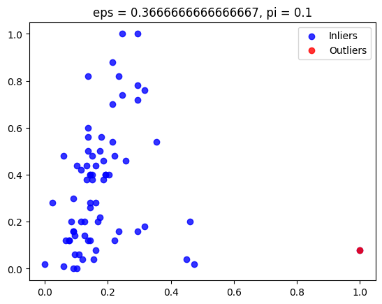

[4 more figures not shown]

```python
# Range of eps values to test
eps_range = np.linspace(0.1, 0.5, 4)

# Range of pi values to test
pi_range = np.linspace(0.01, 0.1, 4)

# Go through all the combinations of eps and pi and plot the results
for eps in eps_range:
    for pi in pi_range:
        outliers = DBOutliers(X_norm, eps, pi)
        plt.scatter(X_norm[:, 0], X_norm[:, 1], alpha=0.8, c='b')
        plt.scatter(X_norm[outliers, 0], X_norm[outliers, 1], alpha=0.8, c='r')
        plt.title('eps = {}, pi = {}'.format(eps, pi))
        plt.legend(['Inliers', 'Outliers'])
        plt.show()
```

B) **[Motivate]**

**Present** the results and **discuss** how the results vary with respect to (1) eps and (2) pi.

**Answer**

eps is a scalar representing the maximum distance for a point to be considered close to another point; and pi is a scalar representing the maximum fraction of other points that can be close to a point for it to be considered an outlier.

From the plots above we see that, the lower the epsilon, then we will have less points that are considered to be neighboors of a point p. Thus, the fraction of points $x$ considered as neighboors to a point $p$, will be lower, and thus we might detect an higher amount of outliers in our dataset.

Further, the higher the value of $pi$, the easier it is for a point to be considered an outlier.

### Task 4.1.3 (3 points)

**NOTE** This is hard but also fun. Since it is not impacting the grade too much, you can choose to invent something new.

A) Propose and **[Implement]** a heuristic method to tune parameters eps, pi.

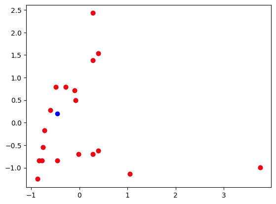

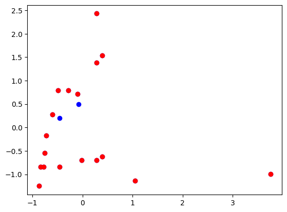

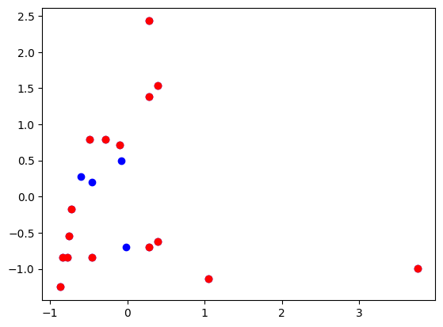

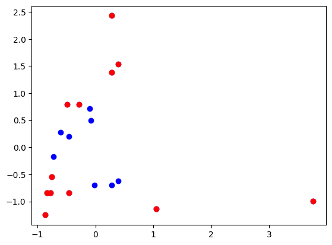

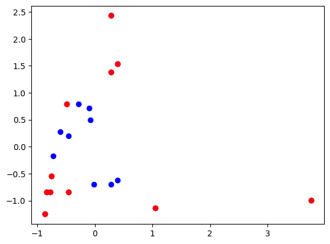

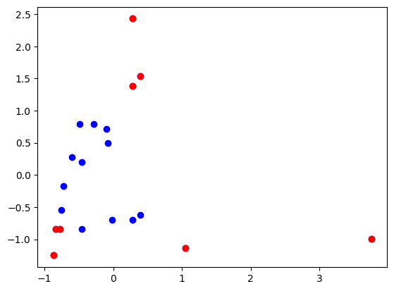

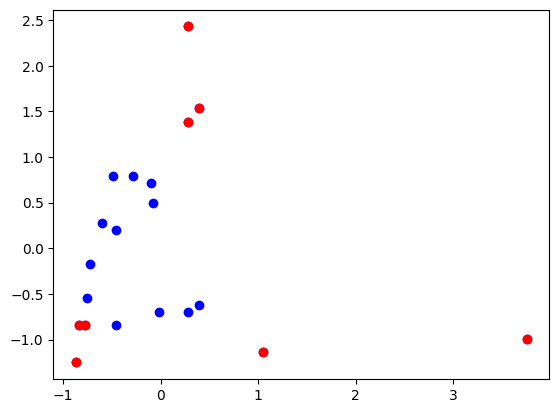

```
(1.5000000000000002, 2.0)
```

```python
import numpy as np
import matplotlib.pyplot as plt

def tune_dboutliers(X, eps=0.5, pi=2, max_iter=10, plot=True):
    # Define threshold for outlier detection
    threshold = pi * np.median(X)

    # Iteratively adjust eps and pi
    for i in range(max_iter):
        # Detect outliers
        outliers = np.where(np.linalg.norm(X, axis=1) > eps)

        # Plot the data and outliers
        if plot:
            plt.scatter(X[:, 0], X[:, 1], color='b')
            plt.scatter(X[outliers, 0], X[outliers, 1], color='r')
            plt.show()

        # Compute the fraction of outliers and adjust eps and pi accordingly
        frac_outliers = len(outliers[0]) / len(X)
        if frac_outliers > 0.05:
            eps += 0.1
        elif frac_outliers < 0.01:
            eps -= 0.1
        else:
            break
        pi = threshold / np.median(X)


    # Return optimized parameters
    eps_opt = eps
    pi_opt = pi
    return eps_opt, pi_opt

print(tune_dboutliers(X_scaled, eps=0.5, pi=2, max_iter=10, plot=True))
```

B) **[Describe]** your algorithm, its main idea, its strengths and its weaknesses

**Answer**

One of the strengths is that it is simple to implement, and can give us better optimal parameters. However, one of its weaknesses, is that it increases and decreases by a fixed value **0.1**, which could be too high or low, depending on the data.

## Task 4.2 LOF (2 points)

**[Describe]**  
Using the parameters eps=0.18, pi=0.2 compare the results of DBOutliers with those obtained by LOF implemented in Week 9. What outliers do you find?

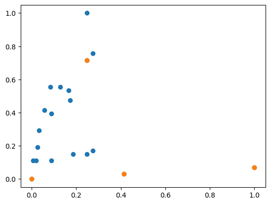

```
1.7187407214542385
3.9138608501845473
2.3518602885345525
1.4024024024024015
```

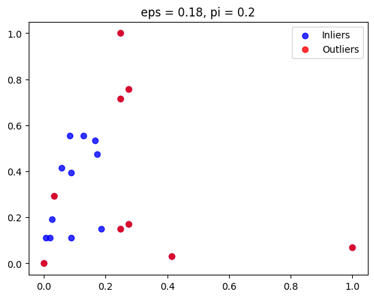

```python
X = X_norm

neighborhoods  = []
kdists         = []

# Find neighbors and kdists
for i, x in enumerate(X):
    n = np.arange(X.shape[0])
    d = np.zeros_like(n, dtype=float)
    for j, x_ in enumerate(X):

        if i == j: continue # skip i it self
        d[j] = np.linalg.norm((x-x_), ord=1)
    args = np.argsort(d)
    ns = n[args]
    ds = d[args]

    kdist =  ds[k-1]
    #print(f'd:{d}\nns:{ns}\nds: {ds}\nkdist:{kdist}')
    kdists.append(kdist)
    neighborhoods.append(ns[ds <= kdist])

# Compute lrds
reach_dist = lambda i, j: max(kdists[j], np.linalg.norm(X[i]-X[j], ord=1))
lrds = []
for i, x in enumerate(X):
    lrd = 0
    for j in neighborhoods[i]:
        lrd += reach_dist(i, j)
    lrd /= len(neighborhoods[i])-1
    lrd = 1 / lrd
    lrds.append(lrd)

def LOF(i):
    lof = np.sum([lrds[j] for j in neighborhoods[i]])/len(neighborhoods[i])
    return lof / lrds[i]

lofs = [LOF(i)> 1.30 for i in range(len(X))]

plt.scatter(X[:,0],X[:,1])
plt.scatter(X[lofs,0],X[lofs,1])
plt.show()

for i in range(len(lofs)):
    if lofs[i]: print(LOF(i))





outliers = DBOutliers(X_norm, 0.18, 0.2)
plt.scatter(X_norm[:, 0], X_norm[:, 1], alpha=0.8, c='b')
plt.scatter(X_norm[outliers, 0], X_norm[outliers, 1], alpha=0.8, c='r')
plt.title('eps = {}, pi = {}'.format(0.18, 0.2))
plt.legend(['Inliers', 'Outliers'])
plt.show()
```

**Answer**

All the outliers found in LOF are also contained in the set of outliers found by DBOutlier, however DBOutlier finds more.